# EE25737: Introduction to Machine Learning

## Fall 99-00, Group 2

## Problem C3: Linear Classification & Decision Trees

### [96101635]

In this problem you will implement linear classification algorithms (perceptron and linear support vector machines), and decision trees.  
Answer the questions in your report, which should not exceed three pages.

```python
# pre-process
# centering all graphs

from IPython.core.display import HTML
HTML("""
<style>
.output_png {
    display: table-cell;
    text-align: center;
    vertical-align: middle;
}
</style>
""")
```

```python
import numpy as np
import pandas as pd
import matplotlib.pyplot as plt
```

## A. Linear Classification

### A1. Load Data

In this section, you are given a data set `data_banknote_authentication.csv` with two classes ($y = 1$, $y = -1$). Each data point has four features obtained from digital image processing of fake and real banknotes, and a label $y=1$ for real backnotes, and $y=-1$ for faked ones. The first four columns are training features and the last column is the label.

Split the data set into two parts. The first `80%` of the data is for training and the remaining `20%` for testing.  
Import data with pandas library. The first 4 columns are training features, denoted by $x_1, x_2, x_3, x_4$, and the 5th column is the label, denoted by $y$.

```python
import pandas as pd

data = pd.read_csv("Datasets\data_banknote_authentication.csv")
data.insert(0,'feature 0',1)

length = len(data)
# considering 80 percent of total data to be our training Set.
trainSetSize = int(0.8*length) + 1

trainSet = data[0:trainSetSize]
testSet = data[trainSetSize:]

cols = data.columns
x_train = trainSet[cols[0:-1]].to_numpy() # Index(['feature 0','feature 1', 'feature 2', 'feature 3', 'feature 4'], dtype='object')
y_train = trainSet[cols[len(cols)-1]].to_numpy() # Label

x_test = testSet[cols[0:-1]].to_numpy() # Index(['feature 0','feature 1', 'feature 2', 'feature 3', 'feature 4'], dtype='object')
y_test = testSet[cols[len(cols)-1]].to_numpy() # Label

data.head()
```

|  | feature 0 | feature 1 | feature 2 | feature 3 | feature 4 | label |
| --- | --- | --- | --- | --- | --- | --- |
| 0 | 1 | -1.7104 | -4.7780 | 6.21090 | 0.39740 | 1 |
| 1 | 1 | 3.7635 | 2.7811 | 0.66119 | 0.34179 | -1 |
| 2 | 1 | 5.3915 | 9.9946 | -3.80810 | -3.36420 | -1 |
| 3 | 1 | -1.8343 | -6.5907 | 5.64290 | 0.54998 | 1 |
| 4 | 1 | 3.5358 | 6.7086 | -0.81857 | 0.47886 | -1 |

### A2. Perceptron Algorithm

In this part, you should implement the perceptron algorithm from the scratch. First, add one dimension with `constant 1` to each data point (i.e. $x_0 = 1$). What is the purpose of this?  
Perform the algorithm for `50000` iterations, and at each `500` iterations calculate and save the error ($\frac{1}{n}\sum_{i=1}^{n} \boldsymbol{1}_{prediction_{i}\neq y_i}$) on the test data, and in the end plot the error against the number of iterations. After the end of the training process, report the final error on the test data and the final weights `w`.

```python
## Implement the algorithm here
import numpy as np
import random

def perceptron(X_tr, Y_tr, X_te, Y_te, max_iter=50000):

    w = np.array([0 for _ in range(len(X_tr[0]))])
    loss_history = list()

    for t in range(1,max_iter + 1):

        # Searching randomly
        indexes = random.sample(range(0,len(X_tr)),len(X_tr))
        # if you dont want to use randomness : replace it with below
        # indexes = [i for i in range(len(X_tr))]

        # finding miss classify
        for i in indexes:
            predict = np.dot(X_tr[i],w)
            if( predict * Y_tr[i] <= 0 ):
                w = w + np.multiply(Y_tr[i],X_tr[i])
                # normalization: w = w / np.linalg.norm(w)
                break

        if(t%500 == 0):
            error = 0
            for i in range(len(X_te)):
                predict = np.sign(np.dot(X_te[i],w))
                if(predict != Y_te[i]):
                    error = error + 1
            error = error/len(X_te)
            loss_history.append(error)

    return w, loss_history
```

```python
## train of training samples
w, loss_history = perceptron(x_train, y_train, x_test, y_test)

print("final W is: ")
print(w)
print("final Loss is: ")
print(loss_history[-1])
```

```
final W is:
[ 242.        -238.47415   -144.229223  -153.796407   -22.3972586]
final Loss is:
0.014598540145985401
```

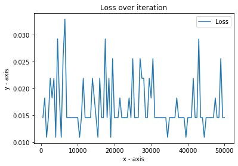

```python
## Plot test error over every 500 iterations
import matplotlib.pyplot as plt

# line 1 points
iteration = [i*500 for i in range(1,len(loss_history)+1)]

# plotting the line 1 points
plt.plot(iteration, loss_history, label = "loss History")

# naming the x axis
plt.xlabel('x - axis')
# naming the y axis
plt.ylabel('y - axis')
# giving a title to my graph
plt.title('Loss over iteration')

# show a legend on the plot
plt.legend(['Loss'])

# function to show the plot
plt.show()
```

### A3. Generalize to non-linear classification

Map data (train and test) $x$ by $\psi(.)$ to the six-dimensional $x'$ as follows: $$x = (x_0, x_1, x_2, x_3, x_4) \overset{\psi}{\implies} x' = (x_0, x_1, x_2, x_3, x_4, x_4^3)$$ Apply Perceptron to $x'$ and repeat part A2.

```python
# Mapping Data
new_x_train = []
new_x_test = []

for i in range(len(x_train)):
    new_x_train.append(np.append(x_train[i],x_train[i][4]**3))

for i in range(len(x_test)):
    new_x_test.append(np.append(x_test[i],x_test[i][4]**3))
```

```python
## train of training samples

w, loss_history = perceptron(new_x_train, y_train, new_x_test, y_test)

print("final W is: ")
print(w)
print("final Loss is: ")
print(loss_history[-1])
```

```
final W is:
[ 11430.         -13531.5622579   -7323.424153    -9220.1838536
  -2852.4305916     166.86535355]
final Loss is:
0.025547445255474453
```

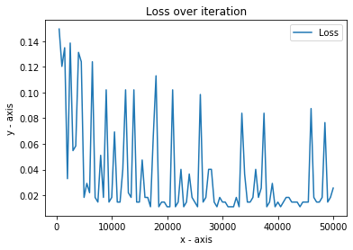

```python
## Plot test error over every 500 iterations
import matplotlib.pyplot as plt

# line 1 points
iteration = [i*500 for i in range(1,len(loss_history)+1)]

# plotting points
plt.plot(iteration, loss_history, label = "loss History")

# naming the x axis
plt.xlabel('x - axis')
# naming the y axis
plt.ylabel('y - axis')
# giving a title to my graph
plt.title('Loss over iteration')

# show a legend on the plot
plt.legend(['Loss'])

# function to show the plot
plt.show()
```

### A4. SVM algorithm

Train the SVM model on the data. In this part of the problem, you should use built-in models of libraries like [Sklearn](https://scikit-learn.org/stable/modules/generated/sklearn.svm.LinearSVC.html#sklearn.svm.LinearSVC) for training and predicting labels of the data. Do not change the default parameters of the model excpet $max\_iter$ if it is needed. Note that you should train the model on the pure form of $x$ (without the added feature $x_0=1$). At last, report final error ($\frac{1}{n}\sum_{i=1}^{n} \boldsymbol{1}_{prediction_{i}\neq y_i}$) on the training and the test samples, and final weights.

```python
import pandas as pd
data = pd.read_csv("Datasets\data_banknote_authentication.csv")
length = len(data)
# considering 80 percent of total data to be our training Set.
trainSetSize = int(0.8*length) + 1
trainSet = data[0:trainSetSize]
testSet = data[trainSetSize:]

cols = data.columns
x_train = trainSet[cols[0:-1]].to_numpy() # Index(['feature 1', 'feature 2', 'feature 3', 'feature 4'], dtype='object')
y_train = trainSet[cols[len(cols)-1]].to_numpy() # Label

x_test = testSet[cols[0:-1]].to_numpy() # Index(['feature 1', 'feature 2', 'feature 3', 'feature 4'], dtype='object')
y_test = testSet[cols[len(cols)-1]].to_numpy() # Label

data.head()
```

|  | feature 1 | feature 2 | feature 3 | feature 4 | label |
| --- | --- | --- | --- | --- | --- |
| 0 | -1.7104 | -4.7780 | 6.21090 | 0.39740 | 1 |
| 1 | 3.7635 | 2.7811 | 0.66119 | 0.34179 | -1 |
| 2 | 5.3915 | 9.9946 | -3.80810 | -3.36420 | -1 |
| 3 | -1.8343 | -6.5907 | 5.64290 | 0.54998 | 1 |
| 4 | 3.5358 | 6.7086 | -0.81857 | 0.47886 | -1 |

```python
## Train a SVM model
from sklearn.svm import LinearSVC
# todo check linearSVC
svclassifier = LinearSVC(max_iter=50000)
svclassifier.fit(x_train, y_train)
```

```
LinearSVC(C=1.0, class_weight=None, dual=True, fit_intercept=True,
          intercept_scaling=1, loss='squared_hinge', max_iter=50000,
          multi_class='ovr', penalty='l2', random_state=None, tol=0.0001,
          verbose=0)
```

```python
# calculate LinearSVC final errors

train_y_pred = svclassifier.predict(x_train)
test_y_pred = svclassifier.predict(x_test)

emp_loss = 0
true_loss = 0

for i in range(len(x_train)):
    if(y_train[i] != train_y_pred[i]):
        emp_loss = emp_loss + 1
emp_loss = emp_loss / len(x_train)

for i in range(len(x_test)):
    if(y_test[i] != test_y_pred[i]):
        true_loss = true_loss + 1
true_loss = true_loss / len(x_test)

print("Emperical Loss: ")
print(emp_loss)

print("True Loss: ")
print(true_loss)

print("Weight: ")
print(svclassifier.coef_)
```

```
Emperical Loss:
0.010018214936247723
True Loss:
0.014598540145985401
Weight:
[[-1.74782371 -1.00507826 -1.22904751 -0.14600092]]
```

### A5. SVM Algorithm on $\psi(x)$

Train the SVM model on the mapped data $x'$. Report the final weight vector, the final error on the training data, and the final error on the test data. Again, for training the model with libraries, the added feature $x'_0=1$ should not be included.

```python
## Train a SVM model, report final errors
# Mapping Data
new_x_train = []
new_x_test = []

for i in range(len(x_train)):
    new_x_train.append(np.append(x_train[i],x_train[i][3]**3))

for i in range(len(x_test)):
    new_x_test.append(np.append(x_test[i],x_test[i][3]**3))

## Train a SVM model, report final errors
from sklearn.svm import SVC
svclassifier = SVC(kernel='linear')#,max_iter=50000)
svclassifier.fit(new_x_train, y_train)
```

```
SVC(C=1.0, cache_size=200, class_weight=None, coef0=0.0,
    decision_function_shape='ovr', degree=3, gamma='auto_deprecated',
    kernel='linear', max_iter=-1, probability=False, random_state=None,
    shrinking=True, tol=0.001, verbose=False)
```

```python
# calculate error

train_y_pred = svclassifier.predict(new_x_train)
test_y_pred = svclassifier.predict(new_x_test)

emp_loss = 0
true_loss = 0

for i in range(len(new_x_train)):
    if(y_train[i] != train_y_pred[i]):
        emp_loss = emp_loss + 1
emp_loss = emp_loss / len(new_x_train)

for i in range(len(new_x_test)):
    if(y_test[i] != test_y_pred[i]):
        true_loss = true_loss + 1
true_loss = true_loss / len(new_x_test)

print("Emperical Loss: ")
print(emp_loss)

print("True Loss: ")
print(true_loss)

print("Weight: ")
print(svclassifier.coef_)
```

```
Emperical Loss:
0.01092896174863388
True Loss:
0.014598540145985401
Weight:
[[-2.45950847e+00 -1.41875226e+00 -1.72020474e+00 -1.92110426e-01
  -6.69808618e-04]]
```

### A6. Conclusion

discuss and compare the resulting weights and errors ($\frac{1}{n}\sum_{i=1}^{n} \boldsymbol{1}_{prediction_{i}\neq y_i}$) of the above methods in your report.

## B. Decision Trees

The dataset `mushrooms.csv` includes the overall features of some population of mushrooms. Each data point has `22` features (e.g. habitat, size, color, etc.) and the goal is to classify mushrooms as poisonous ($y=0$) or edible ($y=1$), by using Decision Trees classifiers. Use built-in models of libraries in [Sklearn](https://scikit-learn.org/stable/modules/generated/sklearn.tree.DecisionTreeClassifier.html) for training and predicting labels of the data. Do not change the default parameters of the model excpet $max\_depth$.

### B1. Load Data

The first cloumn is the label, and the remaining `22` columns are features of data points. Split the data into three sets: the first `70%` for training, the next `20%` for verification, and the remaining `10%` for testing. The validation set is for choosing the best model among all models based on the error ($\frac{1}{n}\sum_{i=1}^{n} \boldsymbol{1}_{prediction_{i}\neq y_i}$). The test set is for estimating the true error of the selected model.  
Import data with pandas library.

```python
import pandas as pd

data = pd.read_csv("Datasets\mushrooms.csv")
length = len(data)

# considering 70 percent of total data to be our training Set.
# 20 percent to be our verification Set
# last 10 percent to be our test Set
_70percent = int(0.7*length)
_90percent = int(0.9*length)

trainSet = data[0:_70percent]
verificationSet = data[_70percent:_90percent]
testSet = data[_90percent:]

cols = data.columns
x_train = trainSet[cols[1:]].to_numpy() # Index(['feature 0','feature 1', 'feature 2', 'feature 3', 'feature 4'], dtype='object')
y_train = trainSet[cols[0]].to_numpy() # Label

x_val = verificationSet[cols[1:]].to_numpy() # Index(['feature 0','feature 1', 'feature 2', 'feature 3', 'feature 4'], dtype='object')
y_val = verificationSet[cols[0]].to_numpy() # Label

x_test = testSet[cols[1:]].to_numpy() # Index(['feature 0','feature 1', 'feature 2', 'feature 3', 'feature 4'], dtype='object')
y_test = testSet[cols[0]].to_numpy() # Label

data.head()
```

|  | class | cap-shape | cap-surface | cap-color | bruises | odor | gill-attachment | gill-spacing | gill-size | gill-color | ... | stalk-surface-below-ring | stalk-color-above-ring | stalk-color-below-ring | veil-type | veil-color | ring-number | ring-type | spore-print-color | population | habitat |
| --- | --- | --- | --- | --- | --- | --- | --- | --- | --- | --- | --- | --- | --- | --- | --- | --- | --- | --- | --- | --- | --- |
| 0 | 1 | 5 | 2 | 4 | 1 | 6 | 1 | 0 | 1 | 4 | ... | 2 | 7 | 7 | 0 | 2 | 1 | 4 | 2 | 3 | 5 |
| 1 | 0 | 5 | 2 | 9 | 1 | 0 | 1 | 0 | 0 | 4 | ... | 2 | 7 | 7 | 0 | 2 | 1 | 4 | 3 | 2 | 1 |
| 2 | 0 | 0 | 2 | 8 | 1 | 3 | 1 | 0 | 0 | 5 | ... | 2 | 7 | 7 | 0 | 2 | 1 | 4 | 3 | 2 | 3 |
| 3 | 1 | 5 | 3 | 8 | 1 | 6 | 1 | 0 | 1 | 5 | ... | 2 | 7 | 7 | 0 | 2 | 1 | 4 | 2 | 3 | 5 |
| 4 | 0 | 5 | 2 | 3 | 0 | 5 | 1 | 1 | 0 | 4 | ... | 2 | 7 | 7 | 0 | 2 | 1 | 0 | 3 | 0 | 1 |

5 rows × 23 columns